# Neural activity data analysis and prediction model design

```r
compute_early_late_spike <- function(spike_matrix) {
  spike_matrix[is.na(spike_matrix)] <- 0
  n_time_bins <- ncol(spike_matrix)
  n_neurons   <- nrow(spike_matrix)
  early_bins <- 1:(n_time_bins %/% 2)
  late_bins  <- ((n_time_bins %/% 2) + 1):n_time_bins
  early_avg_spike <- mean(spike_matrix[, early_bins], na.rm = TRUE)
  late_avg_spike  <- mean(spike_matrix[, late_bins], na.rm = TRUE)

  c(early_avg_spike = early_avg_spike,
    late_avg_spike  = late_avg_spike)
}
integrated_data <- data.frame()

for (i in 1:18) {
  session_i <- session[[i]]
  nTrials <- length(session_i$spks)
  session_df <- data.frame(
    session_id    = i,
    trial_id      = 1:nTrials,
    mouse_name    = session_i$mouse_name[1],
    contrast_left = session_i$contrast_left,
    contrast_right= session_i$contrast_right,
    feedback_type = session_i$feedback_type
  )
  session_df$contrast_diff <- abs(session_i$contrast_left - session_i$contrast_right)
  session_df$success       <- ifelse(session_i$feedback_type == 1, 1, 0)
  spike_features <- lapply(session_i$spks, compute_early_late_spike)
  spike_features_df <- do.call(rbind, spike_features)
  session_df$early_avg_spike <- spike_features_df[, "early_avg_spike"]
  session_df$late_avg_spike  <- spike_features_df[, "late_avg_spike"]
  integrated_data <- rbind(integrated_data, session_df)
}
head(integrated_data)
```

```
##   session_id trial_id mouse_name contrast_left contrast_right feedback_type
## 1          1        1       Cori           0.0            0.5             1
## 2          1        2       Cori           0.0            0.0             1
## 3          1        3       Cori           0.5            1.0            -1
## 4          1        4       Cori           0.0            0.0            -1
## 5          1        5       Cori           0.0            0.0            -1
## 6          1        6       Cori           0.0            0.0             1
##   contrast_diff success early_avg_spike late_avg_spike
## 1           0.5       1      0.03188011     0.04720708
## 2           0.0       1      0.02963215     0.03596730
## 3           0.5       0      0.04509537     0.04713896
## 4           0.0       0      0.03964578     0.02942779
## 5           0.0       0      0.03671662     0.03453678
## 6           0.0       1      0.02445504     0.03024523
```

I confirmed that all sessions share key variables (contrast_left, contrast_right, feedback_type, spks, and mouse_name) and computed derived features such as contrast_diff and success. This ensures a consistent set of variables across all sessions. I also merged the trial-level data from each session into one unified data frame. This integrated dataset now allows me to compare trials from different sessions directly.

```r
integrated_trial_data <- integrated_data
numeric_features <- c("trial_id", "contrast_diff", "early_avg_spike", "late_avg_spike")
integrated_trial_data_scaled <- integrated_trial_data
integrated_trial_data_scaled[numeric_features] <- scale(integrated_trial_data[numeric_features])
summary(integrated_trial_data_scaled[numeric_features])
```

```
##     trial_id        contrast_diff     early_avg_spike   late_avg_spike
##  Min.   :-1.54699   Min.   :-1.1350   Min.   :-1.8422   Min.   :-1.8638
##  1st Qu.:-0.82801   1st Qu.:-1.1350   1st Qu.:-0.7025   1st Qu.:-0.7131
##  Median :-0.08849   Median : 0.2068   Median :-0.1557   Median :-0.1813
##  Mean   : 0.00000   Mean   : 0.0000   Mean   : 0.0000   Mean   : 0.0000
##  3rd Qu.: 0.68185   3rd Qu.: 0.8776   3rd Qu.: 0.4617   3rd Qu.: 0.6146
##  Max.   : 3.03395   Max.   : 1.5485   Max.   : 3.5791   Max.   : 3.1239
```

```r
library(zoo)
all_trial_summary <- integrated_trial_data %>%
  mutate(avg_spike_rate = if("early_avg_spike" %in% names(.)) {
           (early_avg_spike + late_avg_spike) / 2
         } else {
           NA
         }) %>%
  group_by(session_id) %>%
  arrange(trial_id) %>%
  mutate(running_success = rollmean(success, k = 10, fill = NA, align = "right")) %>%
  ungroup()
str(all_trial_summary)
```

```
## tibble [5,081 × 12] (S3: tbl_df/tbl/data.frame)
##  $ session_id     : int [1:5081] 1 2 3 4 5 6 7 8 9 10 ...
##  $ trial_id       : int [1:5081] 1 1 1 1 1 1 1 1 1 1 ...
##  $ mouse_name     : chr [1:5081] "Cori" "Cori" "Cori" "Forssmann" ...
##  $ contrast_left  : num [1:5081] 0 1 0.5 0 0 0.25 1 0 1 0 ...
##  $ contrast_right : num [1:5081] 0.5 1 0 1 1 0 0.5 0.5 0.25 1 ...
##  $ feedback_type  : num [1:5081] 1 -1 1 1 1 1 1 1 1 -1 ...
##  $ contrast_diff  : num [1:5081] 0.5 0 0.5 1 1 0.25 0.5 0.5 0.75 1 ...
##  $ success        : num [1:5081] 1 0 1 1 1 1 1 1 1 0 ...
##  $ early_avg_spike: num [1:5081] 0.0319 0.0375 0.0558 0.0239 0.0245 ...
##  $ late_avg_spike : num [1:5081] 0.0472 0.0432 0.0642 0.0349 0.0409 ...
##  $ avg_spike_rate : num [1:5081] 0.0395 0.0404 0.06 0.0294 0.0327 ...
##  $ running_success: num [1:5081] NA NA NA NA NA NA NA NA NA NA ...
```

```r
head(all_trial_summary)
```

```
## # A tibble: 6 × 12
##   session_id trial_id mouse_name contrast_left contrast_right feedback_type
##        <int>    <int> <chr>              <dbl>          <dbl>         <dbl>
## 1          1        1 Cori                0               0.5             1
## 2          2        1 Cori                1               1              -1
## 3          3        1 Cori                0.5             0               1
## 4          4        1 Forssmann           0               1               1
## 5          5        1 Forssmann           0               1               1
## 6          6        1 Forssmann           0.25            0               1
## # ℹ 6 more variables: contrast_diff <dbl>, success <dbl>,
## #   early_avg_spike <dbl>, late_avg_spike <dbl>, avg_spike_rate <dbl>,
## #   running_success <dbl>
```

I standardized the numeric features (trial_id and contrast_diff) so that differences across sessions are normalized.

```r
pca_data <- all_trial_summary %>%
  select(contrast_diff, avg_spike_rate, running_success)
cat("Dimensions of pca_data (before filtering):", dim(pca_data), "\n")
```

```
## Dimensions of pca_data (before filtering): 5081 3
```

```r
colSums(is.na(pca_data))
```

```
##   contrast_diff  avg_spike_rate running_success
##               0               0             162
```

```r
pca_data_noNA <- na.omit(pca_data)
cat("Dimensions of pca_data_noNA (after na.omit):", dim(pca_data_noNA), "\n")
```

```
## Dimensions of pca_data_noNA (after na.omit): 4919 3
```

```r
variance_vals <- apply(pca_data_noNA, 2, var, na.rm = TRUE)
cat("Variance of each column:\n")
```

```
## Variance of each column:
```

```r
print(variance_vals)
```

```
##   contrast_diff  avg_spike_rate running_success
##      0.13858999      0.00015144      0.03909606
```

```r
zero_var_cols <- names(variance_vals)[variance_vals == 0 | is.na(variance_vals)]

pca_result <- prcomp(scale(pca_data_noNA), center = TRUE, scale. = TRUE)
summary(pca_result)
```

```
## Importance of components:
##                           PC1    PC2    PC3
## Standard deviation     1.0882 1.0180 0.8829
## Proportion of Variance 0.3948 0.3454 0.2598
## Cumulative Proportion  0.3948 0.7402 1.0000
```

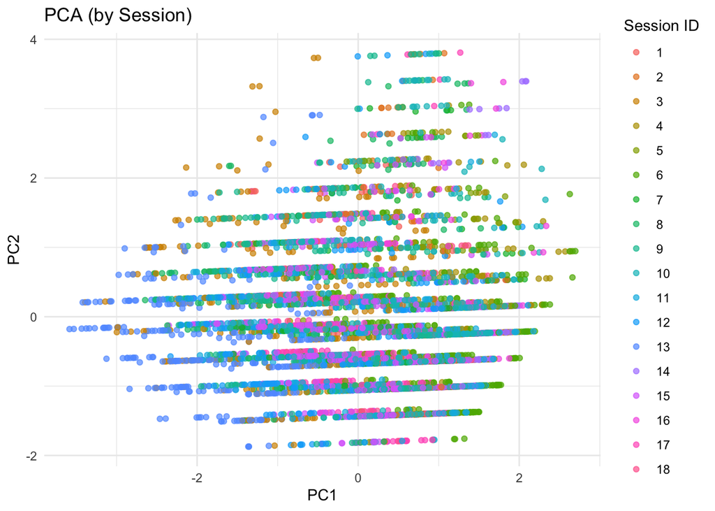

```r
complete_idx <- complete.cases(pca_data)
session_id_noNA <- all_trial_summary$session_id[complete_idx]
mouse_name_noNA <- all_trial_summary$mouse_name[complete_idx]
pca_scores <- as.data.frame(pca_result$x)
pca_scores$session_id <- session_id_noNA
pca_scores$mouse_name <- mouse_name_noNA
ggplot(pca_scores, aes(x = PC1, y = PC2, color = factor(session_id))) +
  geom_point(alpha = 0.7) +
  labs(title = "PCA (by Session)",
       x = "PC1", y = "PC2", color = "Session ID") +
  theme_minimal()
```